# Live Assignment #6

James Hosker, Brian Kolovich, Ireti Fasere, Adarsh Kannan

February 28, 2017

# R Markdown Introduction

This is an R Markdown document for Live Assignement #6 for MSDS 6306-402: Doing Data Science at SMU.

Part of this code was taken from Benjamin Reddy and taken from pages 49-50 of O’Neil and Schutt

# R Libraries Required

• require(gdata)

• require(plyr) #Added by Monnie McGee

• required(car) # Added by James Hosker

Install the gdata, plyr and car packages and load in to R. • library(car) • library(plyr) • library(gdata)

```r
library(car)
library(plyr)
## library(gdata)
```

# Data Files Required to Load and Basic Format of Data

• Change directory to directory where your uncleaned data file rather than using our directory below.

• Again our unlceaned data file is called rollingsales_brooklyn.csv.

• We load the uncleaned data skipping over the first four lines of the file, which is commentary information. The data frame is called “bk”.

• Finally we provide some basic formatting information on the data frame with the head, summary and str functions.

```r
# So, save the file as a csv and use read.csv instead
bk <- read.csv("C:/Users/JHosker/Documents/Rproj/LiveSessionAssignment6/rollingsales_brooklyn.csv",skip=4,header=TRUE)

## Check the data
head(bk)
```

```
##   BOROUGH              NEIGHBORHOOD
## 1       3 BATH BEACH
## 2       3 BATH BEACH
## 3       3 BATH BEACH
## 4       3 BATH BEACH
## 5       3 BATH BEACH
## 6       3 BATH BEACH
##                        BUILDING.CLASS.CATEGORY TAX.CLASS.AT.PRESENT BLOCK
## 1 01  ONE FAMILY DWELLINGS                                        1  6360
## 2 01  ONE FAMILY DWELLINGS                                        1  6361
## 3 01  ONE FAMILY DWELLINGS                                        1  6364
## 4 01  ONE FAMILY DWELLINGS                                        1  6371
## 5 01  ONE FAMILY DWELLINGS                                        1  6371
## 6 01  ONE FAMILY DWELLINGS                                        1  6373
##   LOT EASE.MENT BUILDING.CLASS.AT.PRESENT
```

[output cut: 34 more lines]

```r
summary(bk)
```

```
##     BOROUGH                     NEIGHBORHOOD
##  Min.   :3   BEDFORD STUYVESANT       : 1548
##  1st Qu.:3   EAST NEW YORK            : 1152
##  Median :3   BOROUGH PARK             : 1142
##  Mean   :3   CROWN HEIGHTS            : 1061
##  3rd Qu.:3   SHEEPSHEAD BAY           :  962
##  Max.   :3   BAY RIDGE                :  898
##              (Other)                  :17750
##                                  BUILDING.CLASS.CATEGORY
##  02  TWO FAMILY DWELLINGS                    :6232
##  01  ONE FAMILY DWELLINGS                    :3520
##  03  THREE FAMILY DWELLINGS                  :2242
##  13  CONDOS - ELEVATOR APARTMENTS            :2206
##  10  COOPS - ELEVATOR APARTMENTS             :2094
##  07  RENTALS - WALKUP APARTMENTS             :1815
##  (Other)                                     :6404
##  TAX.CLASS.AT.PRESENT     BLOCK           LOT         EASE.MENT
##  1      :12022        Min.   :   1   Min.   :   1.0   Mode:logical
##  2      : 5374        1st Qu.:1829   1st Qu.:  22.0   NA's:24513
##  4      : 2645        Median :4452   Median :  48.0
##  2A     : 1525        Mean   :4306   Mean   : 303.1
##  2C     : 1086        3rd Qu.:6606   3rd Qu.: 165.0
##  1B     :  658        Max.   :8955   Max.   :9033.0
##  (Other): 1203
##  BUILDING.CLASS.AT.PRESENT
##  B1     : 2265
##  C0     : 2240
##  R4     : 2155
##  D4     : 2090
##  B3     : 1331
##  B2     : 1215
##  (Other):13217
##                                       ADDRESS          APARTMENT.NUMBER
##  360 FURMAN STREET                        :  119               :18783
##  163 WASHINGTON AVENUE                    :  106   4           :  217
##  3041 OCEAN AVENUE                        :   80   6           :  192
##  8 VANDERBILT AVENUE                      :   80   3           :  161
##  597-601 OCEAN PARKWAY                    :   71   1           :  160
##  834 STERLING PLACE                       :   68   2           :  160
##  (Other)                                  :23989   (Other)     : 4840
```

[output cut: 17 more lines]

```
##  Min.   :1.000             B1     : 2266
##  1st Qu.:1.000             C0     : 2242
##  Median :1.000             R4     : 2206
##  Mean   :1.674             D4     : 2090
##  3rd Qu.:2.000             B3     : 1331
##  Max.   :4.000             B2     : 1215
##                            (Other):13163
##        SALE.PRICE         SALE.DATE
##   -         : 9231   6/2/2016  :  343
##   10        :  236   10/20/2015:  212
##   1,200,000 :  142   3/10/2016 :  178
##   700,000   :  125   6/27/2016 :  176
##   750,000   :  119   10/27/2015:  173
##   850,000   :  118   6/29/2016 :  169
##  (Other)    :14542   (Other)   :23262
```

```r
str(bk) # Very handy function!
```

```
## 'data.frame':    24513 obs. of  21 variables:
##  $ BOROUGH                       : int  3 3 3 3 3 3 3 3 3 3 ...
##  $ NEIGHBORHOOD                  : Factor w/ 61 levels "BATH BEACH               ",..: 1 1 1 1 1 1 1 1 1 1 ...
##  $ BUILDING.CLASS.CATEGORY       : Factor w/ 44 levels "01  ONE FAMILY DWELLINGS                    ",..: 1 1 1 1 1 1 1 1 1 1 ...
##  $ TAX.CLASS.AT.PRESENT          : Factor w/ 10 levels "  ","1","1A",..: 2 2 2 2 2 2 2 2 2 2 ...
##  $ BLOCK                         : int  6360 6361 6364 6371 6371 6373 6394 6401 6401 6401 ...
##  $ LOT                           : int  13 11 72 60 79 73 5 7 7 8 ...
##  $ EASE.MENT                     : logi  NA NA NA NA NA NA ...
##  $ BUILDING.CLASS.AT.PRESENT     : Factor w/ 135 levels "  ","A0","A1",..: 7 7 7 9 7 3 7 113 113 113 ...
##  $ ADDRESS                       : Factor w/ 19773 levels "1 BRIGHTON 10TH TERRAC                   ",..: 18380 16694 16287 18328 18383 14096 4237 5070 5070 5037 ...
##  $ APARTMENT.NUMBER              : Factor w/ 1271 levels "            ",..: 1 1 1 1 1 1 1 1 1 1 ...
##  $ ZIP.CODE                      : int  11228 11228 11214 11214 11214 11214 11228 11214 11214 11214 ...
##  $ RESIDENTIAL.UNITS             : int  1 1 1 1 1 1 1 1 1 1 ...
##  $ COMMERCIAL.UNITS              : int  0 0 0 0 0 0 0 1 1 1 ...
##  $ TOTAL.UNITS                   : int  1 1 1 1 1 1 1 2 2 2 ...
##  $ LAND.SQUARE.FEET              : Factor w/ 2543 levels " -   "," 1 ",..: 316 1461 645 1177 1046 1177 1218 46 46 46 ...
##  $ GROSS.SQUARE.FEET             : Factor w/ 3329 levels " -   "," 1,000 ",..: 250 414 3315 1019 1340 425 556 317 317 317 ...
##  $ YEAR.BUILT                    : int  1930 1930 1950 1930 1930 1930 1940 1920 1920 1920 ...
##  $ TAX.CLASS.AT.TIME.OF.SALE     : int  1 1 1 1 1 1 1 1 1 1 ...
##  $ BUILDING.CLASS.AT.TIME.OF.SALE: Factor w/ 137 levels "A0","A1","A2",..: 6 6 6 8 6 2 6 114 114 114 ...
##  $ SALE.PRICE                    : Factor w/ 3414 levels " -   "," 1 ",..: 1 3064 2969 1 2963 2899 3266 1859 1 1 ...
##  $ SALE.DATE                     : Factor w/ 352 levels "1/1/2016","1/10/2016",..: 228 206 254 330 174 99 144 122 38 147 ...
```

# Cleaning and Reformatting of Data

• First using the “[^[:digit:]]”, we are filtering out all characters in each entry that has number (sales.price, gross.square.feet & land.square.feet) and save the digits, we then save the data as numerics and save them as new columns in the “bk” data frame as sales.price.n. gross.sqft, & land.sqft, respectively.

• We change the labels that we will use to lower case.

• Finally to filter the names in the building.class.category, We resave the category names as characters so we can used them later in labeling the data.

```r
## clean/format the data with regular expressions
## More on these later. For now, know that the
## pattern "[^[:digit:]]" refers to members of the variable name that
## start with digits. We use the gsub command to replace them with a blank space.

## We create a new variable that is a "clean' version of sale.price.
## And sale.price.n is numeric, not a factor.

## Get rid of leading digits and any letter characters and convert remaining number string to numeric
bk$SALE.PRICE.N <- as.numeric(gsub("[^[:digit:]]","", bk$SALE.PRICE))
count(is.na(bk$SALE.PRICE.N))
```

```
##       x  freq
## 1 FALSE 15282
## 2  TRUE  9231
```

```r
names(bk) <- tolower(names(bk)) # make all variable names lower case
## Get rid of leading digits, get rid of characters and convert number string to numeric
bk$gross.sqft <- as.numeric(gsub("[^[:digit:]]","", bk$gross.square.feet))
bk$land.sqft <- as.numeric(gsub("[^[:digit:]]","", bk$land.square.feet))
bk$year.built <- as.numeric(as.character(bk$year.built))

## Change building.class.category to character string from integer
bk$building.class.category <- as.character(bk$building.class.category)
```

# Filter the Data, Remove NAs and Zeros. Focus on Family Dwellings

• First thing that we do is we create a subset (called “familydwell”“) of the data frame”bk" to look at only the one, two and three family dwelling data as a a separte data frame with only five columns: building.class.category“,”sale.price.n“,”gross.sqft“,”land.sqft" and “year.built”.

• We then remove (omit) all “NA” data in these three building classifications under “familydwell”.

• We divide the “sales.price.n” column by 1,000 so we can better display the data around sales without any exponential labels. We will then label all graphs with sales in $000s.

• From sale.price.n data, we remove all values < $500.

• From year built data, we remove all zeros.

• From gross.sqft and land.sqft, we checked for values less than 100 sqft but found none after we removed the NAs.

• We relabel the the three main building categories that have too many spaces and characters below in order to better display them in boxplots, plots, histograms, and q-q plots: - “01 ONE FAMILY DWELLINGS” becomes “1 One Dwelling” - “02 TWO FAMILY DWELLINGS” becomes “2 Two Dwelling” - “03 THREE FAMILY DWELLINGS” becomes “3 Three Dwelling”

• We save two cleanded data files: - • Cleaned Dataset on data frame bk: CLEANED_bk_rollsales_brooklyn.csv - This is the orginal date with the cleaning that we orginally received in the code provided in class. Filtering data using “[^[:digit:]]” and omitting NAs. - • Cleaned Dateset on data frame familydwell using our code: CLEANED_familydwelling.csv - This is the CLEANED_rolingsales_brookly.csv with some additional filters for our analysis. We filter out only One, Two and Three Family Dwelling Homes. Additional cleaning includes removing zeros in year.built, removing sales purchase data below $500 and other cleaning documented in the HTML file.

```r
## do a bit of exploration to make sure there's not anything
## weird going on with sale prices
attach(bk)
############################################################
## Required Information and Comparisons
############################################################
building.category <- unique(bk$building.class.category)
familydwell <- bk[bk$building.class.category == building.category[1] |
                    bk$building.class.category == building.category[2] |
                    bk$building.class.category == building.category[3],
                    c("building.class.category","sale.price.n",
                    "gross.sqft","land.sqft", "year.built")]
## Remove or Omit NA
familydwell <- na.omit(familydwell)
## Divide sales.price.n / 1000
familydwell$sale.price.n <- familydwell$sale.price.n/1000
## Remove all sales.price.n < $500
familydwell <- familydwell[(familydwell$sale.price.n > 0.5),]
## Remove all years built equal to zero
familydwell <- familydwell[!(familydwell$year.built==0),]


## Change label to shortened name for one, two and three family dwelling
familydwell$building.class.category[familydwell$building.class.category ==
                                      building.category[1]] <- "1 One Dwelling"
familydwell$building.class.category[familydwell$building.class.category ==
                                      building.category[2]] <- "2 Two Dwelling"
familydwell$building.class.category[familydwell$building.class.category ==
                                      building.category[3]] <- "3 Three Dwelling"
## Write cleanded data frame bk in CSV in R
write.csv(bk, file = "C:/Users/JHosker/Documents/Rproj/LiveSessionAssignment6/CLEANED_bk_rollsales_brooklyn.csv",row.names=FALSE)

## Write cleanded data frame familydwell in CSV in R
write.csv(familydwell, file = "C:/Users/JHosker/Documents/Rproj/LiveSessionAssignment6/CLEANED_familydwelling.csv",row.names=FALSE)
```

# Plots and Interpretation of Data/Plots

## 1. Sales Price for All Family Dwellings

• In this first set of plots, we investigate sales price using the following R functions: “summary” (summary statistics), “boxplot”“,”hist" (histogram), and “qqnorm”" (Q-Q Plot using normal distribution).

• Establish Figure Number variable for numbering of figures.

## Fig.2: This histogram shows the frequency of all homes and their price ranges.

• This histogram shows a strong right skew. There isn’t much of a tail for this histogram, but that is because most of the data points are in the same area, price-wise.

## Fig.3: This Q-Q plot better shows the distribution of the prices of all the homes. This reiterates what the previous two figures showed.

```r
## Summary Statistics for One, Two and Three Family Dwellings Combined
cat("Summary of Sales Price ($000s) for 1,2 & 3 Family Dwellings")
```

```
## Summary of Sales Price ($000s) for 1,2 & 3 Family Dwellings
```

```r
summary(familydwell$sale.price.n)
```

```
##    Min. 1st Qu.  Median    Mean 3rd Qu.    Max.
##     1.0   495.0   750.0   929.1  1125.0 19880.0
```

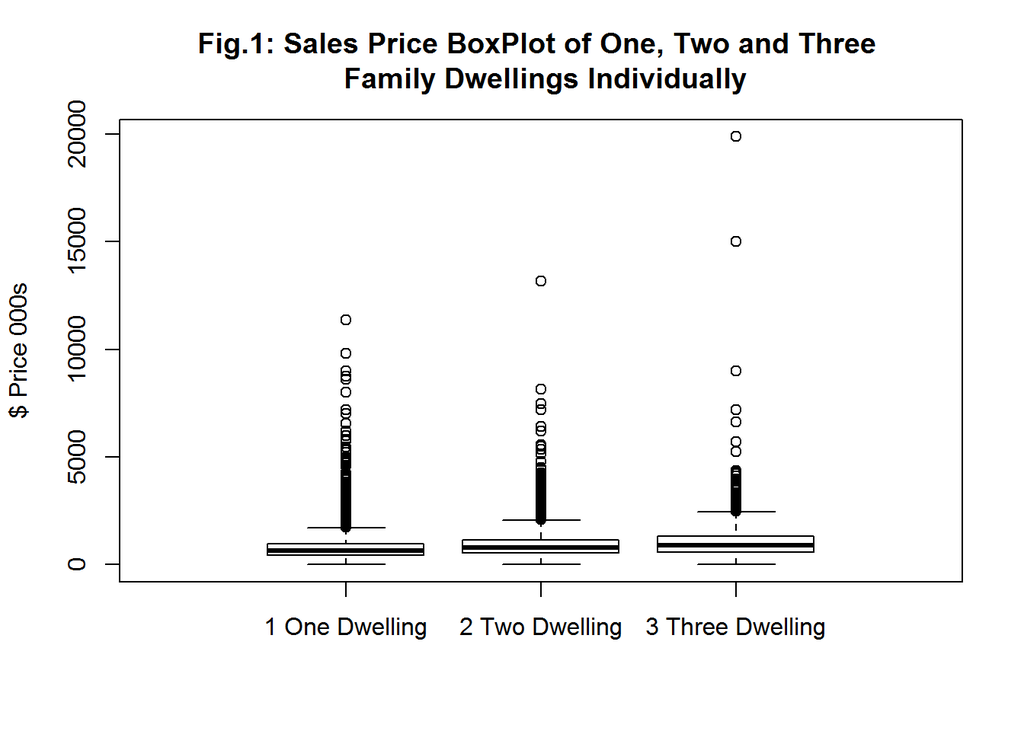

```r
## Sales Price:  Create BoxPlot for One, Two and Three Family Dwellings Combined
boxplot(familydwell$sale.price.n~familydwell$building.class.category,
        xlim=c(0,4),ylab="$ Price 000s",
        main="Fig.1: Sales Price BoxPlot of One, Two and Three \n Family Dwellings Individually")
```

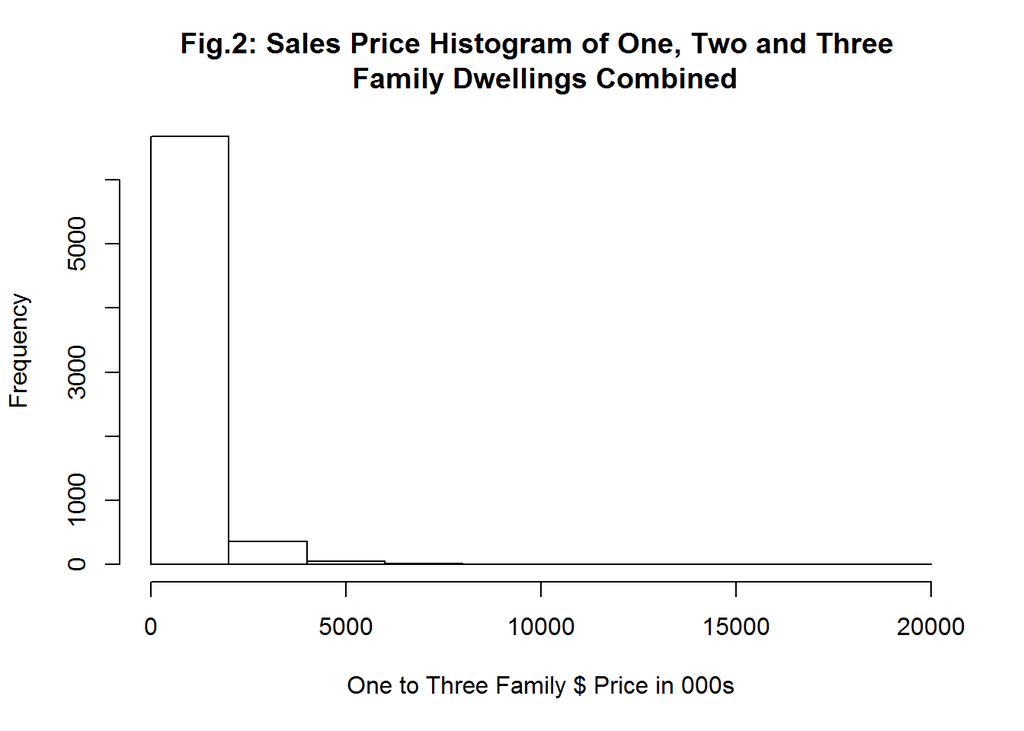

```r
## Sales Price:  Create Histogram for One, Two and Three Family Dwellings Combined
hist(familydwell$sale.price.n, xlab="One to Three Family $ Price in 000s",
     ylab="Frequency",
     main="Fig.2: Sales Price Histogram of One, Two and Three \n Family Dwellings Combined")
```

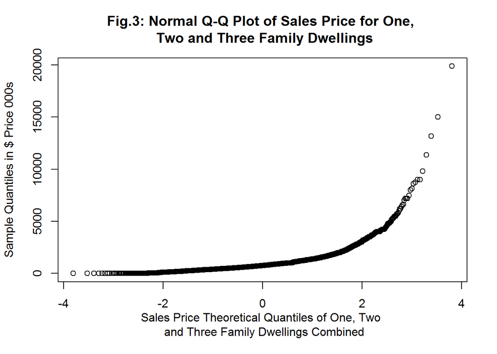

```r
## Sales Price:  Create Q-Q Plot using a normal distribution for One, Two
##   and Three Family Dwellings Combined
qqnorm(familydwell$sale.price.n, xlab="Sales Price Theoretical Quantiles of One, Two \n and Three Family Dwellings Combined",
       ylab="Sample Quantiles in $ Price 000s",
       main="Fig.3: Normal Q-Q Plot of Sales Price for One, \n Two and Three Family Dwellings")
```

## 2. Sales Price vs. Gross Square Feet AND Sales Price vs. Land Square Feet For All Family Dwellings

• In this second set of plots, we investigate sales price vs. gross sqft using the “plot”" (scatterplot) command.

## ANALYSIS:

## Fig.4 and Fig.5: We can generally see that the sales prices increases as the gross square footage increases.

• Overall, the vast majority of the units being sold are around the less than 3,000 square feet range and the less than 5M sales price. There is some evidence of a linear trend although clustered.

• Sales Price goes form 1K to 19.88 Mill with median of 750k and mean of 929.1k. The Q1 (25%) to Q3 (75%) distribuiton iss from 495K to 1,125k.

## Fig.6 and Fig.7: We see sales price vs. land square footage.

• Overall, the vast majority of the units being sold are around the less than 5,000 square feet range and the less than 5M sales price. There is no clear evidence of a linear trend between an increase in sales price to an increase in square footage. There are several outliers associated with increased square footage, in which you see units with more than 5,000 square feet being sold for well under 5M. On the other hand, we see limited sales for units with less than 5,000 square feet being sold at a premium (e.g. over 10M).

```r
## Summary Statistics for One, Two and Three Family Dwellings Combined
cat("Summary of Sales Price ($000s) for 1,2 & 3 Family Dwellings")
```

```
## Summary of Sales Price ($000s) for 1,2 & 3 Family Dwellings
```

```r
summary(familydwell$sale.price.n)
```

```
##    Min. 1st Qu.  Median    Mean 3rd Qu.    Max.
##     1.0   495.0   750.0   929.1  1125.0 19880.0
```

```r
cat("Summary of Gross Sqft for 1,2 & 3 Family Dwellings")
```

```
## Summary of Gross Sqft for 1,2 & 3 Family Dwellings
```

```r
summary(familydwell$gross.sqft)
```

```
##    Min. 1st Qu.  Median    Mean 3rd Qu.    Max.
##     324    1540    2080    2201    2700   20460
```

```r
cat("Summary of Land Sqft for 1,2 & 3 Family Dwellings")
```

```
## Summary of Land Sqft for 1,2 & 3 Family Dwellings
```

```r
summary(familydwell$land.sqft)
```

```
##    Min. 1st Qu.  Median    Mean 3rd Qu.    Max.
##     250    1800    2000    2338    2500   68600
```

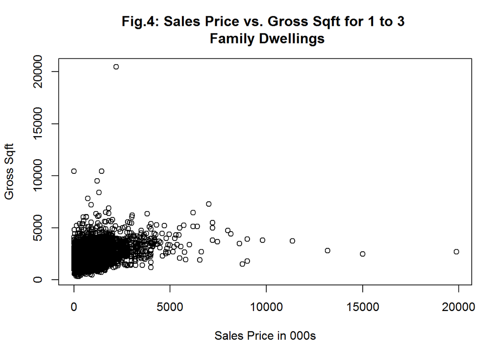

```r
## Graph Sales Price vs. Gross Sqft for One, Two and Three Family Dwellings Combined
plot(familydwell$sale.price.n,familydwell$gross.sqft,
     xlab="Sales Price in 000s", ylab = "Gross Sqft",
     main="Fig.4: Sales Price vs. Gross Sqft for 1 to 3 \n Family Dwellings")
```

```r
## Graph Sales Price vs. Gross Sqft for One, Two and Three Family Dwellings Combined
## We filter out outliers above 10K gross sqft which is two samples:
## 10.424k and 20.457k gross sqft
count(familydwell$gross.sqft[familydwell$gross.sqft > 10000])
```

```
##       x freq
## 1 10424    2
## 2 20457    1
```

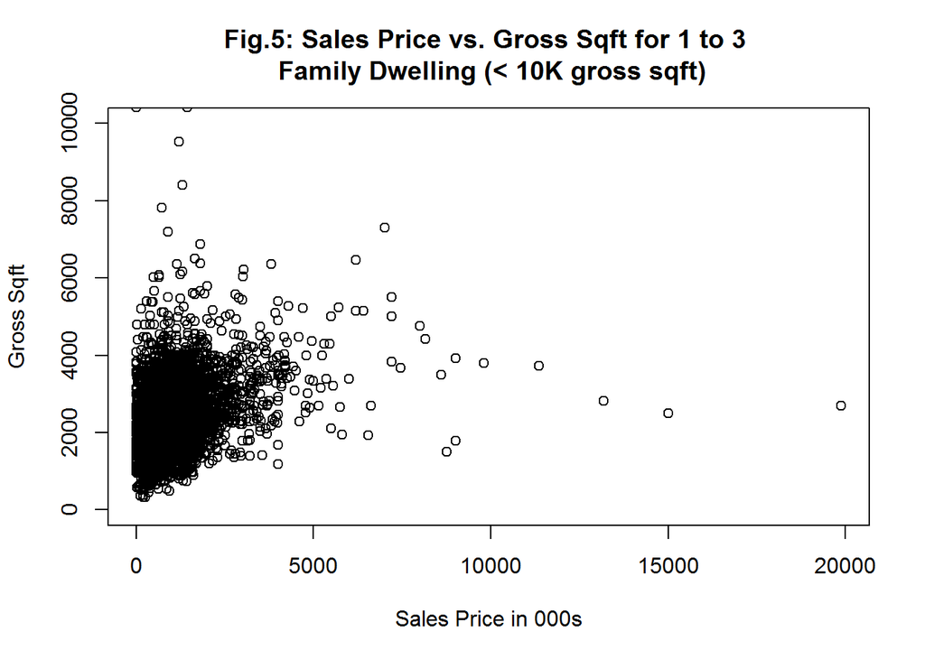

```r
plot(familydwell$sale.price.n,familydwell$gross.sqft,
     xlab="Sales Price in 000s", ylab = "Gross Sqft",ylim=c(1,10000),
     main="Fig.5: Sales Price vs. Gross Sqft for 1 to 3 \n Family Dwelling (< 10K gross sqft)")
```

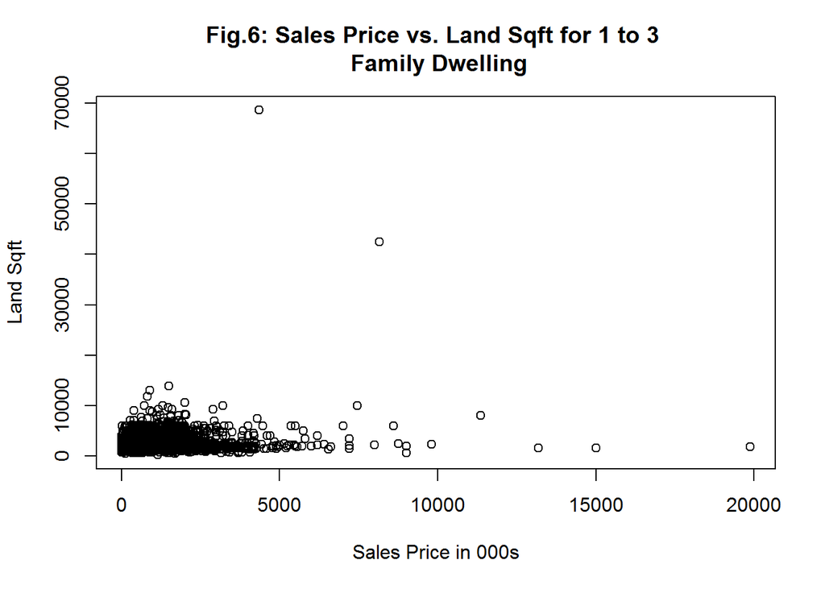

```r
## Graph Sales Price vs. Land Sqft for One, Two and Three Family Dwellings Combined
plot(familydwell$sale.price.n,familydwell$land.sqft,
     xlab="Sales Price in 000s", ylab = "Land Sqft",
     main="Fig.6: Sales Price vs. Land Sqft for 1 to 3 \n Family Dwelling")
```

```r
## Graph Sales Price vs. Land Sqft for One, Two and Three Family Dwellings Combined
## We filter out outliers above 15k which is two samples: 42.5 and 68.6k samples
count(familydwell$land.sqft[familydwell$land.sqft > 15000])
```

```
##       x freq
## 1 42500    1
## 2 68600    1
```

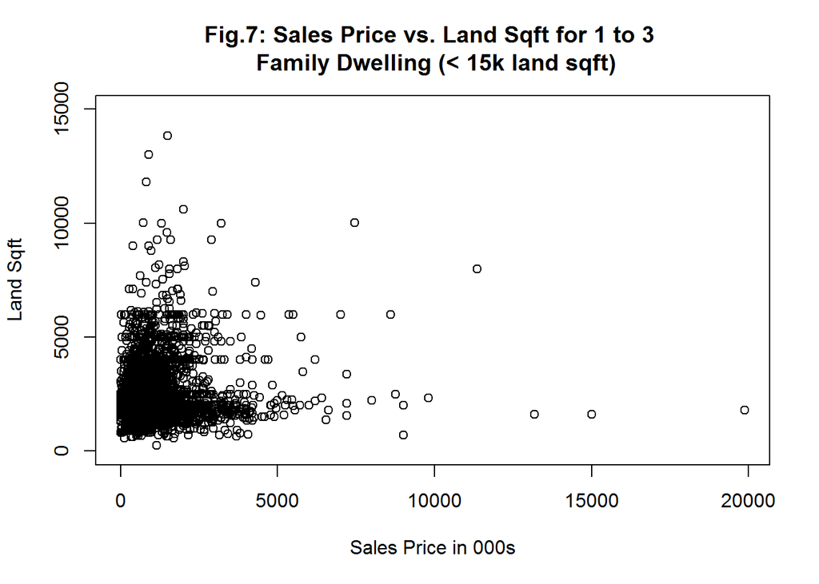

```r
plot(familydwell$sale.price.n,familydwell$land.sqft,
     xlab="Sales Price in 000s", ylab = "Land Sqft", ylim=c(1,15000),
     main="Fig.7: Sales Price vs. Land Sqft for 1 to 3 \n Family Dwelling (< 15k land sqft)")
```

## 3. Sales Price vs. Year Built For All Family Dwellings

• In this third set of plots, we investigate sales using the “plot”" (scatterplot) command.

## ANALYSIS:

## Fig.8: Year Built vs. Sales Price

• For the homes built in the 19th century, the data is scarce in terms of the number of observations, and there are no clear trends to speak of, outside of the fact that the majority of the units were sold for under $5M.

• For homes built in the 1940s through the 1970s, the sales price starts to decline and the number of units being sold remains steady throughout this time period.

• For homes built in the 1980s onward, we see a noticeable uptick in the number of units being sold and the sales price, the latter being particularly evident for homes built in the last 5-10 years.

```r
## Summary Statistics for One, Two and Three Family Dwellings Combined
cat("Summary of Year Built for 1,2 & 3 Family Dwellings")
```

```
## Summary of Year Built for 1,2 & 3 Family Dwellings
```

```r
summary(familydwell$year.built)
```

```
##    Min. 1st Qu.  Median    Mean 3rd Qu.    Max.
##    1800    1910    1925    1927    1931    2015
```

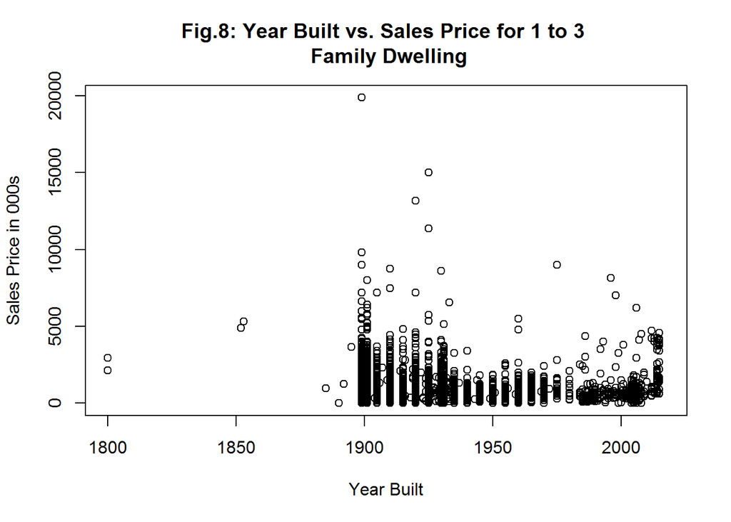

```r
## Individual Graph Sales Price vs. Year Built for One, Two and Three Family Dwellings Combined
plot(familydwell$year.built,familydwell$sale.price.n, xlab = "Year Built",
     ylab="Sales Price in 000s",xlim=c(1800,2017),
     main="Fig.8: Year Built vs. Sales Price for 1 to 3 \n Family Dwelling")
```

## 4. Year Built, Gross Square Feet Land Square Feet For All Family Dwellings

• In this fourth set of plots, we investigate these elements using the “boxplot”" and “hist” (histogram) commands. • For gross and land square feet we fitler out outliers greater than 15K, which eliminates only one sample for gross square footage and two from land square footage.

## ANALYSIS:

## Fig.9: Here we have year built of the one, two and three family dwellings representing individual differences between distributions.

• One Family Dwelling: The first boxplot from fig 9 shows the one- family dwelling with minimum houses that were built in 1900. The bottom 25% of the houses were built in 1920. The horizontal line indicates that 50% of the houses were built around 1925(median). On the average, houses were built in 1925 which also indicate the mean year of houses built. Same mean and median would also indicate a no skew. Top 25% of the houses built in 1930 and maximum houses built in 1940 and above, excluding outliers. The outliers indicate 3 or more houses built below the minimum and more outliers houses built above the maximum.

• Two Family Dwelling: The second boxplot from fig 9 shows the two-family dwelling and minimum houses that were built around 1875. The bottom 25% of the houses were built in 1900. The horizontal line indicates that 50% of the houses were built around 1920 (median). On the average, more houses were built above 1920 which is above the median. A larger mean than median would also indicate a positive skew. Top 25% of the houses were built in 1930 and maximum houses built in 1975 and above, excluding outliers. The outliers indicate 1 house built below the minimum (1800) and more outliers houses built above the maximum.

• Three Family Dwelling The third boxplot from fig 9 shows the three-family dwelling and minimum houses that were built in 1885. The bottom 25% of the houses were built in 1895. The horizontal line indicates that 50% of the houses were built around 1915 (median). On the average, more houses were built above 1915 which is above the median. A larger mean than median would also indicate a positive skew. Top 25% of the houses built in 1940 and maximum houses built in 1995 and above, excluding outliers. The outliers indicate 1 house built below the minimum (1800) and more outliers houses built above the maximum.

## In fig 11, the Histogram graph gives a quick visual summary of the data.

• It is easy to see that the average frequency is around 2500 gross sqft, with less houses below 2500 gross sqft, and a few as large as 5000 gross sqft, with very low frequency for 7500 gross sqft. The frequency distribution tells us a lot about probability. The shape of this distribution, is right skewed histogram. This data is not a true representative of the population, therefore applies to only this study.

## In fig 13, the Histogram graph gives a quick visual summary of the data.

• It is easy to see that the average combined frequency is around 2500 and 5000 land sqft, with less land around 7500sqft which is below 10000 land sqft. The frequency distribution tells us a lot about probability. The shape of this distribution, is right skewed histogram. This data is not a true representative of the population, therefore applies to only this study.

```r
## Summary Statistics for One, Two and Three Family Dwellings Combined
cat("Summary of Year Built for 1,2 & 3 Family Dwellings")
```

```
## Summary of Year Built for 1,2 & 3 Family Dwellings
```

```r
summary(familydwell$year.built)
```

```
##    Min. 1st Qu.  Median    Mean 3rd Qu.    Max.
##    1800    1910    1925    1927    1931    2015
```

```r
cat("Summary of Gross Sqft for 1,2 & 3 Family Dwellings")
```

```
## Summary of Gross Sqft for 1,2 & 3 Family Dwellings
```

```r
summary(familydwell$gross.sqft)
```

```
##    Min. 1st Qu.  Median    Mean 3rd Qu.    Max.
##     324    1540    2080    2201    2700   20460
```

```r
cat("Summary of Land Sqft for 1,2 & 3 Family Dwellings")
```

```
## Summary of Land Sqft for 1,2 & 3 Family Dwellings
```

```r
summary(familydwell$land.sqft)
```

```
##    Min. 1st Qu.  Median    Mean 3rd Qu.    Max.
##     250    1800    2000    2338    2500   68600
```

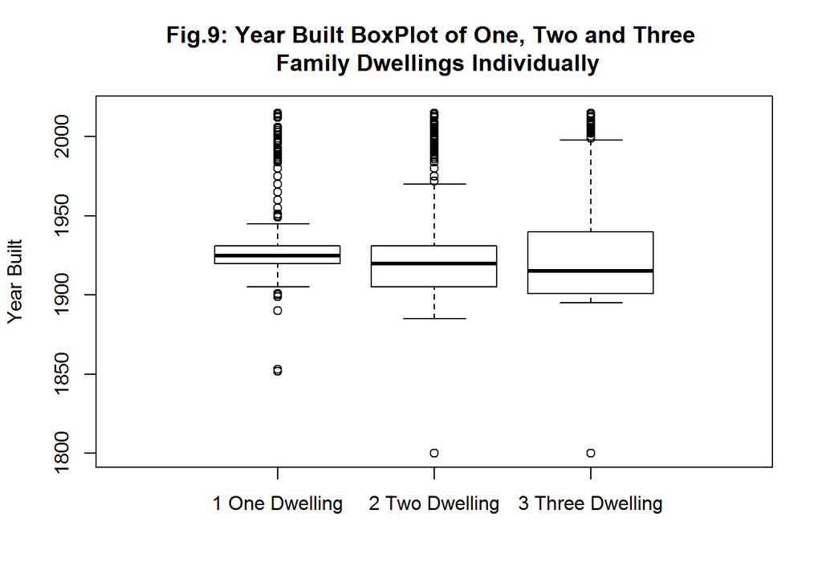

```r
## Year Built:  Create BoxPlot for One, Two and Three Family Dwellings Combined
boxplot(familydwell$year.built~familydwell$building.class.category,
        xlim=c(0,4),ylab="Year Built", ylim=c(1800,2017),
        main="Fig.9: Year Built BoxPlot of One, Two and Three \n Family Dwellings Individually")
```

```r
## Gross Sqft:  Create BoxPlot for One, Two and Three Family Dwellings Combined
## We filter out outliers above 15k which is two samples:  20.457k sample
count(familydwell$gross.sqft[familydwell$gross.sqft > 15000])
```

```
##       x freq
## 1 20457    1
```

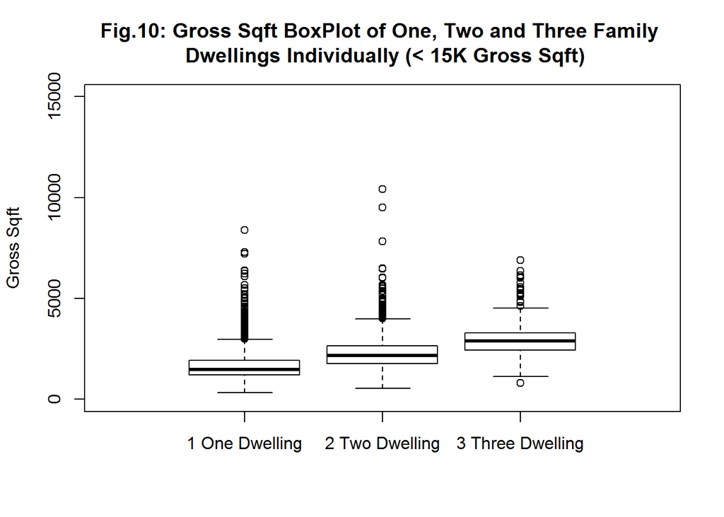

```r
boxplot(familydwell$gross.sqft~familydwell$building.class.category,
        xlim=c(0,4),ylab="Gross Sqft", ylim=c(1,15000),
        main="Fig.10: Gross Sqft BoxPlot of One, Two and Three Family \n Dwellings Individually (< 15K Gross Sqft)")
```

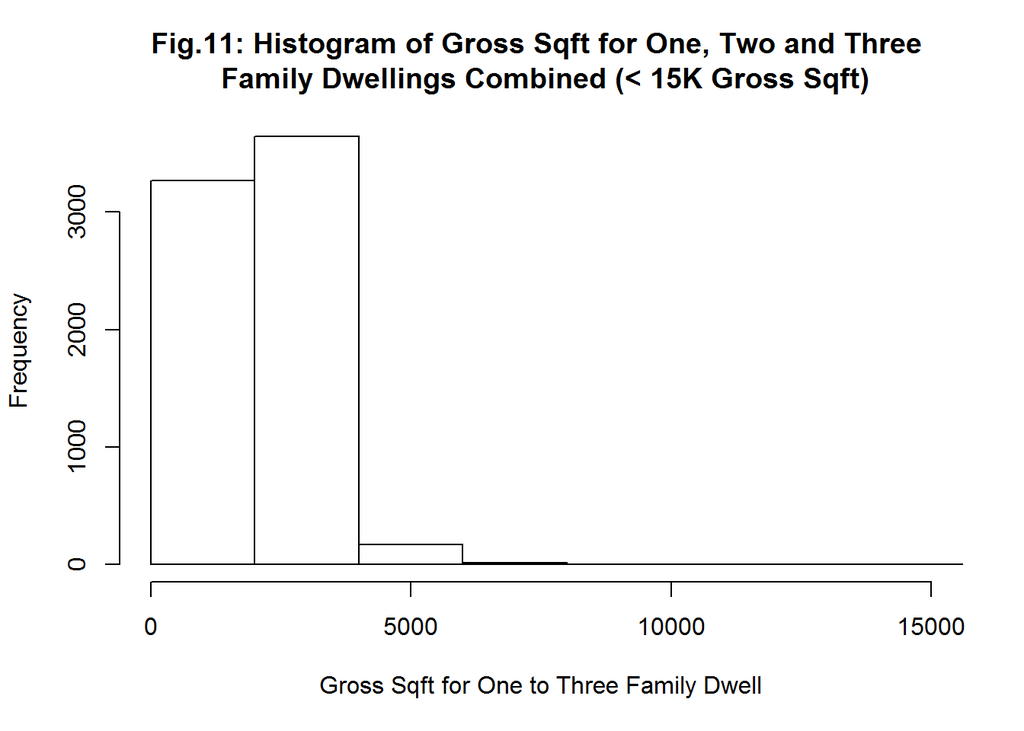

```r
hist(as.numeric(familydwell$gross.sqft), xlim=c(1,15000),
  xlab="Gross Sqft for One to Three Family Dwell", ylab="Frequency",
  main="Fig.11: Histogram of Gross Sqft for One, Two and Three \n Family Dwellings Combined (< 15K Gross Sqft)")
```

```r
## Land Sqft:  Create BoxPlot for One, Two and Three Family Dwellings Combined
## We filter out outliers above 15k which is two samples: 42.5 and 68.6k samples
count(familydwell$land.sqft[familydwell$land.sqft > 15000])
```

```
##       x freq
## 1 42500    1
## 2 68600    1
```

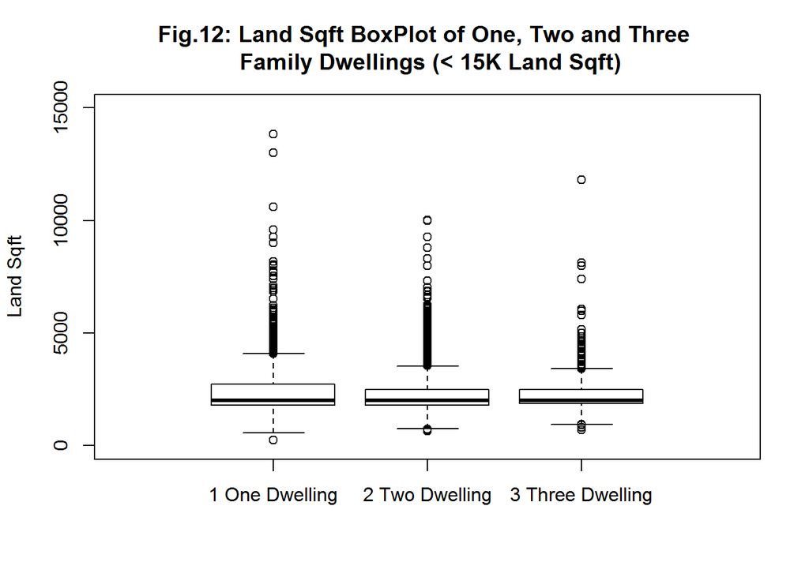

```r
boxplot(familydwell$land.sqft~familydwell$building.class.category,
        xlim=c(0,4),ylab="Land Sqft", ylim=c(1,15000),
        main="Fig.12: Land Sqft BoxPlot of One, Two and Three \n Family Dwellings (< 15K Land Sqft)")
```

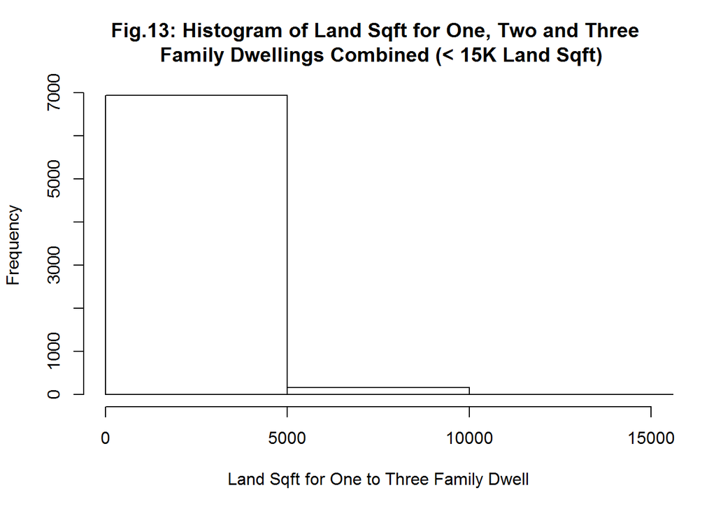

```r
hist(as.numeric(familydwell$land.sqft), xlim=c(1,15000),
     xlab="Land Sqft for One to Three Family Dwell", ylab="Frequency",
     main="Fig.13: Histogram of Land Sqft for One, Two and Three \n Family Dwellings Combined (< 15K Land Sqft)")
```

## 5. Sales Price for Each Individual Dwelling (One, Two, Three)

• In this fifth set of plots, we investigate these elements with the “hist” (histogram) and “qqnorm” (q-q plot) command of only sales price data for each individual category of family dwellings.

• We could also do the same for other variables but stop here. Other variables are gross square feet; year built; and land per square feet.

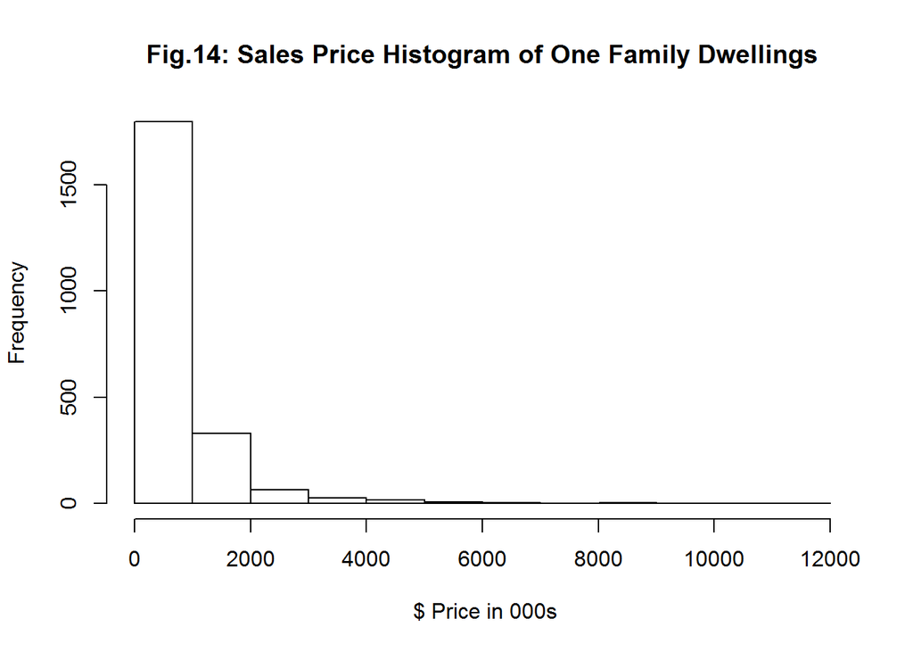

```r
#############################################################################
## Create Same Information for each individual Family Group for sales.price.n
#############################################################################

## Create Historgrams of Each Family Dwelling Individually
hist(familydwell$sale.price.n[familydwell$building.class.category == "1 One Dwelling"],
     xlab=" $ Price in 000s", ylab="Frequency", main="Fig.14: Sales Price Histogram of One Family Dwellings")
```

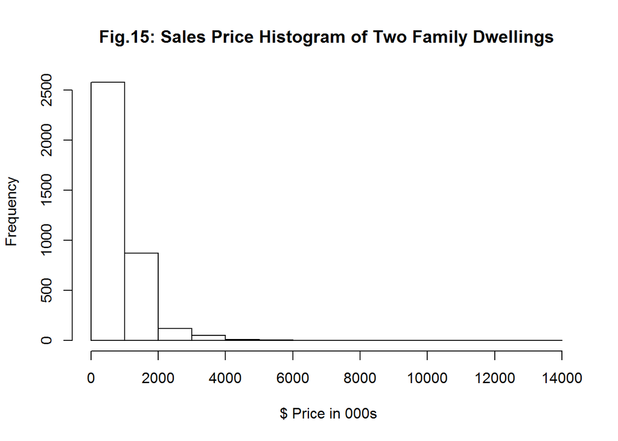

```r
hist(familydwell$sale.price.n[familydwell$building.class.category == "2 Two Dwelling"],
     xlab=" $ Price in 000s", ylab="Frequency", main="Fig.15: Sales Price Histogram of Two Family Dwellings")
```

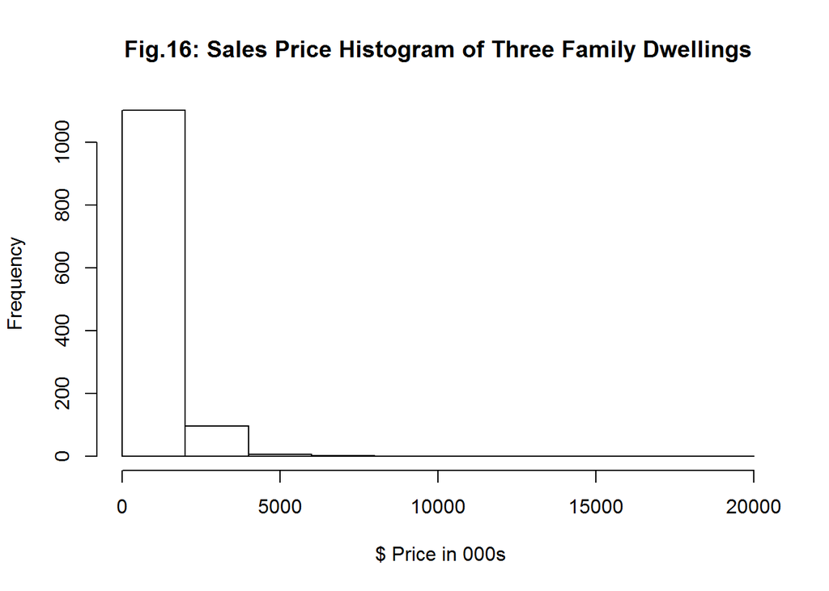

```r
hist(familydwell$sale.price.n[familydwell$building.class.category == "3 Three Dwelling"],
     xlab=" $ Price in 000s", ylab="Frequency", main="Fig.16: Sales Price Histogram of Three Family Dwellings")
```

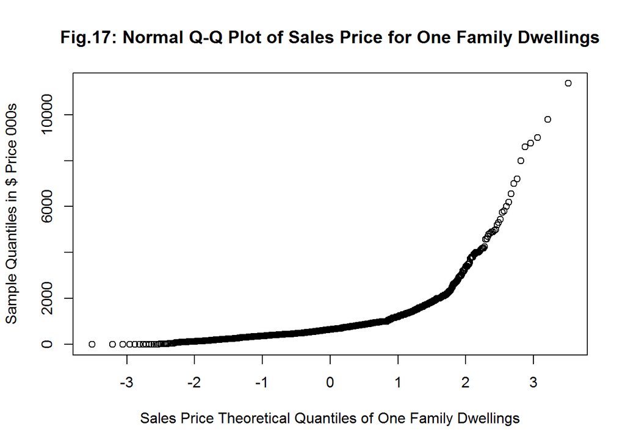

```r
## Create Q-Q Plot for One, Two and Three Family Dwellings Individually
qqnorm(familydwell$sale.price.n[familydwell$building.class.category == "1 One Dwelling"],
       xlab="Sales Price Theoretical Quantiles of One Family Dwellings",
       ylab="Sample Quantiles in $ Price 000s",
       main="Fig.17: Normal Q-Q Plot of Sales Price for One Family Dwellings")
```

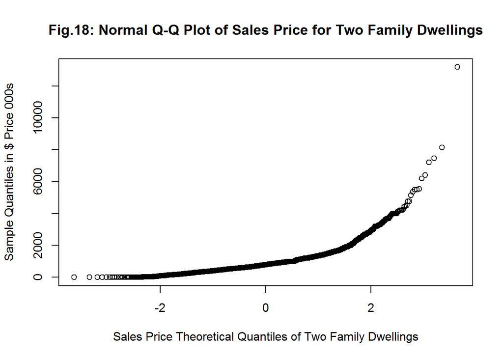

```r
qqnorm(familydwell$sale.price.n[familydwell$building.class.category == "2 Two Dwelling"],
       xlab="Sales Price Theoretical Quantiles of Two Family Dwellings",
       ylab="Sample Quantiles in $ Price 000s",
       main="Fig.18: Normal Q-Q Plot of Sales Price for Two Family Dwellings")
```

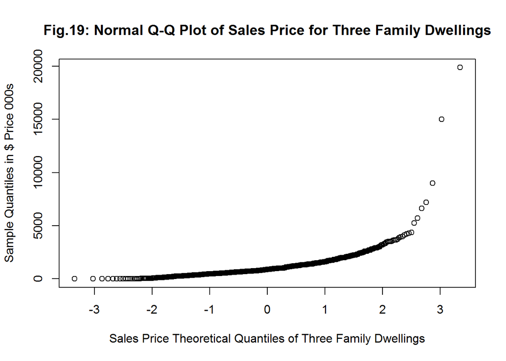

```r
qqnorm(familydwell$sale.price.n[familydwell$building.class.category == "3 Three Dwelling"],
       xlab="Sales Price Theoretical Quantiles of Three Family Dwellings",
       ylab="Sample Quantiles in $ Price 000s",
       main="Fig.19: Normal Q-Q Plot of Sales Price for Three Family Dwellings")
```

# This ends the HTML file for Live Assignment #6